# The Importance of Client–Canine Contact in Canine-Assisted Interventions: A Randomized Controlled Trial

This document provides the R code and output for all analyses, as well as code for reproducing tables and figures in the manuscript. In addition to allowing for reviewing of the code, it also provides additional information that would not fit in the manuscript, such as figures and analyses conducted to evaluate test assumptions.

Analyses were conducted in R using Jupyter Hub.

# Setup

## Load Packages

```r
library(tidyr)
library(purrr)
library(numform)
library(psych)
library(dplyr)
library(ggplot2)
library(ggtext)
library(forcats)
library(lmtest)
library(sandwich)
```

## User-defined Functions

### format_num

This function has no impact on the analyses. I used it to format the numbers before putting them in a table.

```r
format_num <- function(x) {
    x <- sprintf("%0.2f", x)
    gsub("-", "−", x)
}
```

### t_test

```r
t_test <- function(x, h = c("post", "follow-up")) {
    h <- match.arg(h)
    wb_vars <- c("FS", "PANAS-PA", "SCS", "SHS", "Composite")
    ib_vars <- c("Stress", "Homesick", "Lonely", "PANAS-NA")

    diff <- x$t2 - x$t1

    if (unique(x$measure) %in% wb_vars) {
        alt <- "greater"
    } else if (unique(x$measure) %in% ib_vars) {
        alt <- "less"
    } else {
        alt <- "two.sided"
    }

    result <- t.test(x = diff, alternative = alt)
    d <- psych::t2d(result$statistic, n1 = result$parameter + 1)
    d90 <- psych::d.ci(d, n1 = result$parameter + 1, alpha = .10)
    d95 <- psych::d.ci(d, n1 = result$parameter + 1)
    data.frame(
        t = abs(result$statistic),
        df = result$parameter,
        p = result$p.value,
        d = d95[[2]],
        d90.LL = d90[[1]],
        d90.UL = d90[[3]],
        d95.LL = d95[[1]],
        d95.UL = d95[[3]]
    )
}
```

### ParallelAnalysis

This function conducts parallel analysis, which is generally considered the gold standard for determining the number of factors to retain in exploratory factor analysis. Used in the exploratory analyses.

```r
ParallelAnalysis <- function(n_obs, n_vars, percentiles = c(.5, .95),
                             n_iterations = 1000) {
    rdta <- replicate(
        n = n_iterations,
        expr = eigen(
            x = cor(matrix(rnorm(n_obs * n_vars), ncol = n_vars)),
            symmetric = TRUE,
            only.values = TRUE)$values,
        simplify = "array"
    )

    pa_eigvals <- apply(rdta,
                        MARGIN = 1,
                        FUN = quantile,
                        probs = percentiles)

    return(t(pa_eigvals))
}
```

### ctt and multi_ctt

These stand for Classical Test Theory. They just give pretty output of classical test theory reliability analysis.

```r
ctt <- function(x, varnames, keys, drop = NULL, pretty_varnames = NULL) {
    if (!is.null(drop)) {
        include <- varnames[-which(varnames %in% drop)]
    } else {
        include <- varnames
    }

    if (is.null(pretty_varnames)) pretty_varnames <- varnames

    result <- suppressMessages(psych::alpha(x[, include], keys = keys))

    dt <- data.frame(
        variable = include,
        rdrop = f_num(result$item.stats$r.drop, digits = 2)
    )

    out <- data.frame(
        variable = varnames,
        Item = pretty_varnames
    )

    out <- left_join(
        x = out,
        y = dt,
        by = "variable"
    )

    list(rdrop = out[, c("Item", "rdrop")], alpha = f_num(result$total$raw_alpha, digits = 2))
}

multi_ctt <- function(x, varnames, keys, drop, pretty_varnames = NULL) {
    # Step 1
    out <- ctt(x, varnames, keys, drop = NULL, pretty_varnames)
    for (i in seq_along(drop)) {
        res <- ctt(x, varnames, keys, drop = drop[1:i], pretty_varnames)
        out[[1]] <- left_join(
            x = out[[1]],
            y = res[[1]],
            by = "Item"
        )
        out[[2]] <- c(out[[2]], res[[2]])
    }
    names(out[[1]]) <- c("Item", paste0("Step", seq_len(length(drop) + 1)))
    out[[1]] <- sapply(out[[1]], function(x) ifelse(is.na(x), "-", x))
    out
}
```

## Data Import and Wrangling

```r
dta <- read.csv("canine-contact-scored.csv")
dta$group <- factor(dta$group,
    levels = c("Handler", "Indirect", "Direct")
)
dta$time <- factor(
    dta$time,
    levels = c("t1", "t2")
)
head(dta)
```

A data.frame: 6 × 13

|  | pid <int> | group <fct> | time <fct> | pets <chr> | stress <int> | homesickness <int> | loneliness <dbl> | panas_pa <dbl> | panas_na <dbl> | shs <dbl> | scs <dbl> | flourishing <dbl> | integration <int> |
| --- | --- | --- | --- | --- | --- | --- | --- | --- | --- | --- | --- | --- | --- |
| 1 | 1 | Handler | t1 | No | 2 | 3 | 2.25 | 3.2 | 1.0 | 2.333333 | 3.900000 | 6.125 | 1 |
| 2 | 1 | Handler | t2 | No | 2 | 3 | 1.70 | 3.8 | 1.2 | 3.333333 | 3.800000 | 6.000 | 2 |
| 3 | 2 | Direct | t1 | No | 2 | 4 | 1.90 | 3.0 | 1.8 | 3.333333 | 5.150000 | 5.250 | 4 |
| 4 | 2 | Direct | t2 | No | 1 | 2 | 1.60 | 3.2 | 1.0 | 4.000000 | 5.263158 | 6.000 | 4 |
| 5 | 3 | Indirect | t1 | No | 4 | 3 | 2.25 | 2.8 | 1.6 | 2.666667 | 4.100000 | 5.375 | 3 |
| 6 | 3 | Indirect | t2 | No | 3 | 2 | 2.25 | 3.0 | 1.6 | 3.333333 | 4.150000 | 5.375 | 3 |

### Reshape the Data

This is just rearranging the data frame so that each measure is a column. This simplifies the code later by allowing us to apply a function to the data at each level of the `measure` column. The analyses are conducted using the `dta_diff`.

```r
dta_longer <- pivot_longer(
    dta,
    cols = c(-pid, -group, -time, -pets),
    names_to = "measure",
    values_to = "score"
)

head(dta_longer)

dta_longer$measure <- factor(
    dta_longer$measure,
levels = c(
    "flourishing",
    "panas_pa",
    "scs",
    "shs",
    "integration",
    "stress",
    "homesickness",
    "loneliness",
    "panas_na"
  ),
  labels = c(
    "FS",
    "PANAS-PA",
    "SCS-R",
    "SHS",
    "Integration",
    "Stress",
    "Homesick",
    "Lonely",
    "PANAS-NA"
  )
)

dta_diff <- pivot_wider(
    dta_longer,
    names_from = "time",
    values_from = "score"
)

dta_diff$group.measure <- paste(dta_diff$group, dta_diff$measure, sep = ".")

dta_diff$diff21 <- dta_diff$t2 - dta_diff$t1

head(dta_diff)
```

A tibble: 6 × 6

| pid <int> | group <fct> | time <fct> | pets <chr> | measure <chr> | score <dbl> |
| --- | --- | --- | --- | --- | --- |
| 1 | Handler | t1 | No | stress | 2.000000 |
| 1 | Handler | t1 | No | homesickness | 3.000000 |
| 1 | Handler | t1 | No | loneliness | 2.250000 |
| 1 | Handler | t1 | No | panas_pa | 3.200000 |
| 1 | Handler | t1 | No | panas_na | 1.000000 |
| 1 | Handler | t1 | No | shs | 2.333333 |

A tibble: 6 × 8

| pid <int> | group <fct> | pets <chr> | measure <fct> | t1 <dbl> | t2 <dbl> | group.measure <chr> | diff21 <dbl> |
| --- | --- | --- | --- | --- | --- | --- | --- |
| 1 | Handler | No | Stress | 2.000000 | 2.000000 | Handler.Stress | 0.00 |
| 1 | Handler | No | Homesick | 3.000000 | 3.000000 | Handler.Homesick | 0.00 |
| 1 | Handler | No | Lonely | 2.250000 | 1.700000 | Handler.Lonely | -0.55 |
| 1 | Handler | No | PANAS-PA | 3.200000 | 3.800000 | Handler.PANAS-PA | 0.60 |
| 1 | Handler | No | PANAS-NA | 1.000000 | 1.200000 | Handler.PANAS-NA | 0.20 |
| 1 | Handler | No | SHS | 2.333333 | 3.333333 | Handler.SHS | 1.00 |

# Scale Descriptives

These are descriptive values for each scale.

Note that the analyses were conducted on either change scores (H1 and H2) or the residual post-intervention score, after controlling for pre-test score. As such, the tests do not make any assumptions about the distributions of these measures. Values such as skew and kurtosis are provided for descriptive purposes.

```r
round(describe(dta[dta$time == "t1", -1:-4]), 3)
round(describe(dta[dta$time == "t2", -1:-4]), 3)
```

A psych: 9 × 13

|  | vars <dbl> | n <dbl> | mean <dbl> | sd <dbl> | median <dbl> | trimmed <dbl> | mad <dbl> | min <dbl> | max <dbl> | range <dbl> | skew <dbl> | kurtosis <dbl> | se <dbl> |
| --- | --- | --- | --- | --- | --- | --- | --- | --- | --- | --- | --- | --- | --- |
| stress | 1 | 284 | 3.208 | 0.971 | 3.000 | 3.206 | 1.483 | 1.00 | 5.0 | 4.00 | -0.145 | -0.619 | 0.058 |
| homesickness | 2 | 284 | 2.088 | 1.205 | 2.000 | 1.943 | 1.483 | 1.00 | 5.0 | 4.00 | 0.738 | -0.652 | 0.071 |
| loneliness | 3 | 284 | 2.040 | 0.530 | 1.950 | 2.008 | 0.519 | 1.05 | 3.6 | 2.55 | 0.513 | -0.246 | 0.031 |
| panas_pa | 4 | 284 | 3.289 | 0.683 | 3.400 | 3.312 | 0.593 | 1.20 | 5.0 | 3.80 | -0.355 | 0.356 | 0.041 |
| panas_na | 5 | 284 | 1.979 | 0.705 | 1.800 | 1.911 | 0.593 | 1.00 | 4.0 | 3.00 | 0.710 | -0.331 | 0.042 |
| shs | 6 | 284 | 3.311 | 0.876 | 3.333 | 3.348 | 0.988 | 1.00 | 5.0 | 4.00 | -0.328 | -0.334 | 0.052 |
| scs | 7 | 284 | 4.416 | 0.824 | 4.550 | 4.478 | 0.890 | 1.60 | 5.9 | 4.30 | -0.735 | 0.354 | 0.049 |
| flourishing | 8 | 284 | 5.678 | 0.782 | 5.875 | 5.745 | 0.741 | 2.75 | 7.0 | 4.25 | -0.877 | 0.780 | 0.046 |
| integration | 9 | 284 | 3.222 | 1.048 | 3.000 | 3.224 | 1.483 | 1.00 | 5.0 | 4.00 | -0.229 | -0.589 | 0.062 |

A psych: 9 × 13

|  | vars <dbl> | n <dbl> | mean <dbl> | sd <dbl> | median <dbl> | trimmed <dbl> | mad <dbl> | min <dbl> | max <dbl> | range <dbl> | skew <dbl> | kurtosis <dbl> | se <dbl> |
| --- | --- | --- | --- | --- | --- | --- | --- | --- | --- | --- | --- | --- | --- |
| stress | 1 | 284 | 2.373 | 1.030 | 2.000 | 2.311 | 1.483 | 1.000 | 5.00 | 4.000 | 0.466 | -0.453 | 0.061 |
| homesickness | 2 | 284 | 1.894 | 1.113 | 1.000 | 1.711 | 0.000 | 1.000 | 5.00 | 4.000 | 1.065 | 0.141 | 0.066 |
| loneliness | 3 | 284 | 1.914 | 0.535 | 1.850 | 1.889 | 0.593 | 1.000 | 3.55 | 2.550 | 0.400 | -0.540 | 0.032 |
| panas_pa | 4 | 284 | 3.296 | 0.787 | 3.400 | 3.298 | 0.890 | 1.200 | 6.80 | 5.600 | 0.136 | 0.696 | 0.047 |
| panas_na | 5 | 284 | 1.613 | 0.671 | 1.400 | 1.500 | 0.593 | 1.000 | 4.40 | 3.400 | 1.418 | 1.837 | 0.040 |
| shs | 6 | 284 | 3.534 | 0.823 | 3.667 | 3.558 | 0.988 | 1.333 | 5.00 | 3.667 | -0.285 | -0.460 | 0.049 |
| scs | 7 | 284 | 4.534 | 0.867 | 4.700 | 4.601 | 0.890 | 0.000 | 6.00 | 6.000 | -0.954 | 1.843 | 0.051 |
| flourishing | 8 | 284 | 5.742 | 0.780 | 5.875 | 5.803 | 0.741 | 2.750 | 7.00 | 4.250 | -0.829 | 0.654 | 0.046 |
| integration | 9 | 283 | 3.353 | 1.026 | 3.000 | 3.374 | 1.483 | 1.000 | 5.00 | 4.000 | -0.331 | -0.407 | 0.061 |

# Test Hypothesis 1

Research question: Does the intervention improve subjective well-being?

Hypothesis: Participants in each of the three conditions will report significant improvements in subjective well-being from pre-to-post intervention.

## Descriptive Statistics

The paired samples *t* test is just a one-sample *t* test conducted on the change scores. So, the assumptions of the test are about the change scores. Below are descriptive statistics for the change scores.

```r
desc_h1 <- pivot_wider(
    dta_diff[, c("pid", "group", "measure", "diff21")],
    names_from = measure,
    values_from = diff21
)

desc_h1 <- describe(desc_h1[, -1:-2])

round(desc_h1, 3)
```

A psych: 9 × 13

|  | vars <dbl> | n <dbl> | mean <dbl> | sd <dbl> | median <dbl> | trimmed <dbl> | mad <dbl> | min <dbl> | max <dbl> | range <dbl> | skew <dbl> | kurtosis <dbl> | se <dbl> |
| --- | --- | --- | --- | --- | --- | --- | --- | --- | --- | --- | --- | --- | --- |
| Stress | 1 | 284 | -0.835 | 0.953 | -1.0 | -0.842 | 1.483 | -4.00 | 2.000 | 6.000 | -0.065 | 0.397 | 0.057 |
| Homesick | 2 | 284 | -0.194 | 0.854 | 0.0 | -0.171 | 0.000 | -3.00 | 2.000 | 5.000 | -0.436 | 1.864 | 0.051 |
| Lonely | 3 | 284 | -0.126 | 0.229 | -0.1 | -0.121 | 0.222 | -1.15 | 0.650 | 1.800 | -0.366 | 1.758 | 0.014 |
| PANAS-PA | 4 | 284 | 0.007 | 0.511 | 0.0 | 0.013 | 0.297 | -1.80 | 2.600 | 4.400 | 0.089 | 3.167 | 0.030 |
| PANAS-NA | 5 | 284 | -0.366 | 0.510 | -0.2 | -0.331 | 0.297 | -3.00 | 1.200 | 4.200 | -0.965 | 3.058 | 0.030 |
| SHS | 6 | 284 | 0.223 | 0.410 | 0.0 | 0.211 | 0.494 | -1.00 | 1.667 | 2.667 | 0.397 | 0.712 | 0.024 |
| SCS-R | 7 | 284 | 0.118 | 0.412 | 0.1 | 0.124 | 0.232 | -2.90 | 2.200 | 5.100 | -1.490 | 18.206 | 0.024 |
| FS | 8 | 284 | 0.064 | 0.351 | 0.0 | 0.057 | 0.185 | -1.00 | 1.375 | 2.375 | 0.351 | 1.211 | 0.021 |
| Integration | 9 | 283 | 0.131 | 0.695 | 0.0 | 0.154 | 0.000 | -3.00 | 2.000 | 5.000 | -0.432 | 3.614 | 0.041 |

## Histograms

Histograms of the difference scores.

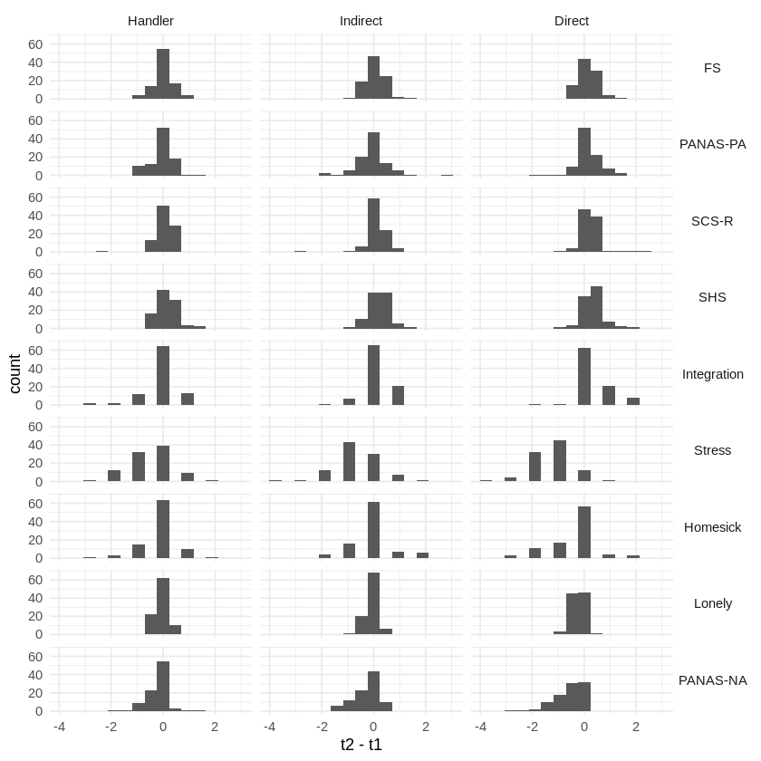

```r
ggplot(dta_diff, aes(x = t2 - t1)) +
    facet_grid(rows = vars(measure), cols = vars(group)) +
    geom_histogram(bins = 15) +
    theme_minimal() +
    theme(strip.text.y = element_text(angle = 0))
```

```r
results1 <- lapply(split(dta_diff, dta_diff$group.measure), t_test, h = "post")

results1 <- bind_rows(results1, .id = "Group.Measure")

results1 <- separate(
    results1,
    Group.Measure,
    into = c("Group", "Measure"),
    sep = "\\."
)

results1$Group <- factor(results1$Group, levels = c("Handler", "Indirect", "Direct"))

results1$Measure <- factor(results1$Measure, levels = levels(dta_diff$measure))

results1 <- results1[order(results1$Group, results1$Measure), ]

rownames(results1) <- NULL

results1
```

A data.frame: 27 × 10

| Group <fct> | Measure <fct> | t <dbl> | df <dbl> | p <dbl> | d <dbl> | d90.LL <dbl> | d90.UL <dbl> | d95.LL <dbl> | d95.UL <dbl> |
| --- | --- | --- | --- | --- | --- | --- | --- | --- | --- |
| Handler | FS | 0.2182676 | 93 | 4.138494e-01 | 0.02251258 | -0.147221060 | 0.192128500 | -0.17972863 | 0.22463347 |
| Handler | PANAS-PA | 0.9237790 | 93 | 8.210040e-01 | -0.09528053 | -0.265066876 | 0.075013623 | -0.29764294 | 0.10759107 |
| Handler | SCS-R | 0.6288815 | 93 | 5.309683e-01 | 0.06486418 | -0.105143219 | 0.234523801 | -0.13767854 | 0.26705991 |
| Handler | SHS | 3.0553471 | 93 | 1.466669e-03 | 0.31513499 | 0.140464314 | 0.488160012 | 0.10717531 | 0.52147980 |
| Handler | Integration | 1.2642567 | 93 | 2.092973e-01 | -0.13039812 | -0.300428930 | 0.040329391 | -0.33307007 | 0.07296862 |
| Handler | Stress | 5.4237260 | 93 | 2.299012e-07 | -0.55941463 | -0.740573555 | -0.375483872 | -0.77562323 | -0.34059398 |
| Handler | Homesick | 1.7144738 | 93 | 4.488626e-02 | -0.17683447 | -0.347349252 | -0.005378766 | -0.38010840 | 0.02737496 |
| Handler | Lonely | 2.7803816 | 93 | 3.285873e-03 | -0.28677446 | -0.459156314 | -0.112888118 | -0.49233575 | -0.07973336 |
| Handler | PANAS-NA | 5.2105989 | 93 | 5.639591e-07 | -0.53743224 | -0.717678843 | -0.354509113 | -0.75253489 | -0.31979456 |
| Indirect | FS | 1.7564329 | 94 | 4.113561e-02 | 0.18020622 | 0.009598236 | 0.349865768 | -0.02299259 | 0.38246182 |
| Indirect | PANAS-PA | 0.8215723 | 94 | 7.933004e-01 | -0.08429154 | -0.253129871 | 0.084992547 | -0.28551930 | 0.11737819 |
| Indirect | SCS-R | 2.3151966 | 94 | 2.277800e-02 | 0.23753416 | 0.065772907 | 0.408054398 | 0.03299290 | 0.44084744 |
| Indirect | SHS | 5.0246541 | 94 | 1.198886e-06 | 0.51551863 | 0.334535463 | 0.693946801 | 0.30017196 | 0.72843575 |
| Indirect | Integration | 2.1619512 | 94 | 3.316112e-02 | 0.22181152 | 0.050395422 | 0.392068371 | 0.01766779 | 0.42480207 |
| Indirect | Stress | 7.1173652 | 94 | 1.081636e-10 | -0.73022626 | -0.918607898 | -0.538436211 | -0.95517926 | -0.50217794 |
| Indirect | Homesick | 0.6279294 | 94 | 2.657864e-01 | -0.06442419 | -0.233188170 | 0.104681536 | -0.26555211 | 0.13704467 |
| Indirect | Lonely | 4.1009251 | 94 | 4.371153e-05 | -0.42074604 | -0.595806703 | -0.243553316 | -0.62958244 | -0.20984925 |
| Indirect | PANAS-NA | 5.9112079 | 94 | 2.714523e-08 | -0.60647714 | -0.788745574 | -0.421274311 | -0.82404005 | -0.38617501 |
| Direct | FS | 3.3857567 | 94 | 5.186909e-04 | 0.34737131 | 0.172665993 | 0.520289965 | 0.13938803 | 0.55361121 |
| Direct | PANAS-PA | 2.3132034 | 94 | 1.144605e-02 | 0.23732966 | 0.065573017 | 0.407846322 | 0.03279376 | 0.44063859 |
| Direct | SCS-R | 5.5406018 | 94 | 2.736870e-07 | 0.56845375 | 0.385080859 | 0.749046699 | 0.35030115 | 0.78399046 |
| Direct | SHS | 7.8764449 | 94 | 2.897339e-12 | 0.80810620 | 0.611707895 | 1.000821510 | 0.57463984 | 1.03829348 |
| Direct | Integration | 5.0025133 | 93 | 2.662956e-06 | 0.51596985 | 0.333999147 | 0.695356229 | 0.29945002 | 0.73003238 |
| Direct | Stress | 15.4004846 | 94 | 9.510848e-28 | -1.58005638 | -1.830792184 | -1.323604138 | -1.88025161 | -1.27592883 |
| Direct | Homesick | 4.0112455 | 94 | 6.057669e-05 | -0.41154510 | -0.586314895 | -0.234690154 | -0.62003108 | -0.20103957 |
| Direct | Lonely | 9.7137481 | 94 | 3.730558e-16 | -0.99660953 | -1.201192067 | -0.787744131 | -1.24112917 | -0.74848120 |
| Direct | PANAS-NA | 10.1735671 | 94 | 3.932684e-17 | -1.04378596 | -1.251615268 | -0.831537743 | -1.29222532 | -0.79168106 |

## Create a Pretty Table of the Results for H1

The code below simply formats the results so that they look nice and can be copied and pasted into MS Word to create a table, without having to manually enter the table data (which is time consuming and prone to human error).

```r
tbl1 <- results1

tbl1$p <- f_num(tbl1$p, digits = 3)
tbl1$p <- ifelse(tbl1$p == ".000", "<.001", tbl1$p)

tbl1$df <- as.character(tbl1$df)

tbl1[, sapply(tbl1, is.numeric)] <- sapply(
    tbl1[, sapply(tbl1, is.numeric)],
    format_num
)

tbl1$Measure <- as.character(tbl1$Measure)

tbl1 <- split(tbl1[-1], tbl1$Group)

keepers1 <- c("Measure", "t", "df", "p", "d", "d95.LL", "d95.UL")

tbl1 <- rbind(
    c(names(tbl1)[[1]], rep("", length(keepers1) - 1)),
    tbl1[[1]][, keepers1],
    c(names(tbl1)[[2]], rep("", length(keepers1) - 1)),
    tbl1[[2]][, keepers1],
    c(names(tbl1)[[3]], rep("", length(keepers1) - 1)),
    tbl1[[3]][, keepers1]
)

rownames(tbl1) <- NULL
```

Copy and paste this output into MS Word, and then use Insert > Table > Convert Text to Table. There is still some formatting that needs to be done, but not much!

```r
write.csv(tbl1, row.names = FALSE, quote = FALSE)
```

```
Measure,t,df,p,d,d95.LL,d95.UL
Handler,,,,,,
FS,0.22,93,.414,0.02,−0.18,0.22
PANAS-PA,0.92,93,.821,−0.10,−0.30,0.11
SCS-R,0.63,93,.531,0.06,−0.14,0.27
SHS,3.06,93,.001,0.32,0.11,0.52
Integration,1.26,93,.209,−0.13,−0.33,0.07
Stress,5.42,93,<.001,−0.56,−0.78,−0.34
Homesick,1.71,93,.045,−0.18,−0.38,0.03
Lonely,2.78,93,.003,−0.29,−0.49,−0.08
PANAS-NA,5.21,93,<.001,−0.54,−0.75,−0.32
Indirect,,,,,,
FS,1.76,94,.041,0.18,−0.02,0.38
PANAS-PA,0.82,94,.793,−0.08,−0.29,0.12
SCS-R,2.32,94,.023,0.24,0.03,0.44
SHS,5.02,94,<.001,0.52,0.30,0.73
Integration,2.16,94,.033,0.22,0.02,0.42
Stress,7.12,94,<.001,−0.73,−0.96,−0.50
Homesick,0.63,94,.266,−0.06,−0.27,0.14
Lonely,4.10,94,<.001,−0.42,−0.63,−0.21
PANAS-NA,5.91,94,<.001,−0.61,−0.82,−0.39
Direct,,,,,,
FS,3.39,94,.001,0.35,0.14,0.55
PANAS-PA,2.31,94,.011,0.24,0.03,0.44
SCS-R,5.54,94,<.001,0.57,0.35,0.78
SHS,7.88,94,<.001,0.81,0.57,1.04
Integration,5.00,93,<.001,0.52,0.30,0.73
Stress,15.40,94,<.001,−1.58,−1.88,−1.28
Homesick,4.01,94,<.001,−0.41,−0.62,−0.20
Lonely,9.71,94,<.001,−1.00,−1.24,−0.75
PANAS-NA,10.17,94,<.001,−1.04,−1.29,−0.79
```

## Figure for H1

The code below creates the figure used in the manuscript (although using a different font).

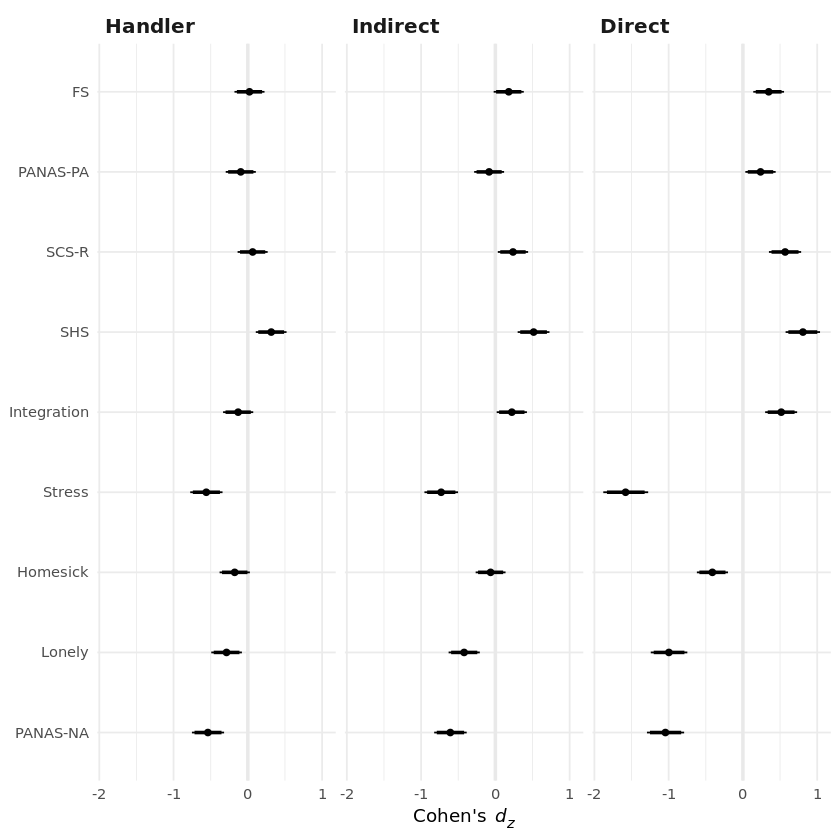

```r
ggplot(results1, aes(x = d, y = fct_rev(Measure))) +
    facet_wrap(~Group) +
    geom_vline(xintercept = 0, size = 1.0, colour = "#e9e9e9") +
    geom_linerange(aes(xmin = d95.LL, xmax = d95.UL)) +
    geom_linerange(aes(xmin = d90.LL, xmax = d90.UL), size = 1) +
    geom_point() +
    theme_minimal(base_family = "Fira Sans") +
    labs(
        x = "Cohen's *d<sub>z</sub>*",
        y = NULL
    ) +
    theme(
        axis.title.x = element_markdown(),
        strip.text = element_text(size = 12, hjust = 0, face = "bold")
    )
```

```r
ggsave("h1.png", width = 6.5, height = 4, dpi = 320)
```

# ANCOVAS

```r
contrasts(dta_diff$group) <- cbind(
    handler_v_dog = c(-1, 0.5, 0.5),
    indirect_v_direct = c(0, -1, 1)
)

contrasts(dta_diff$group)
```

A matrix: 3 × 2 of type dbl

|  | handler_v_dog | indirect_v_direct |
| --- | --- | --- |
| Handler | -1.0 | 0 |
| Indirect | 0.5 | -1 |
| Direct | 0.5 | 1 |

```r
models <- lapply(
    split(dta_diff, dta_diff$measure),
    function(x) aov(t2 ~ t1 + group, data = x)
)

corrected_models <- lapply(
    models,
    function(x) lmtest::coeftest(x, vcov. = sandwich::vcovHC(x))
)
```

## Q–Q Plots

These plots show the relationship between the theoretical quantiles (i.e., normally distributed residuals) and the sample quantiles. If the sample residuals are normally distributed, the theoretical and sample quantiles should fall along the line.

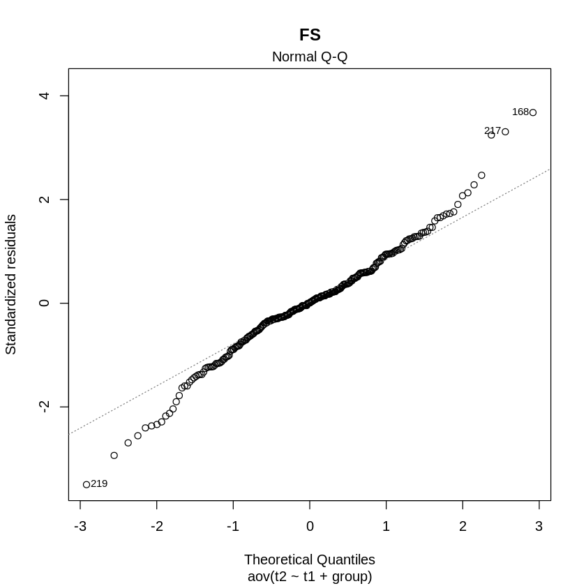

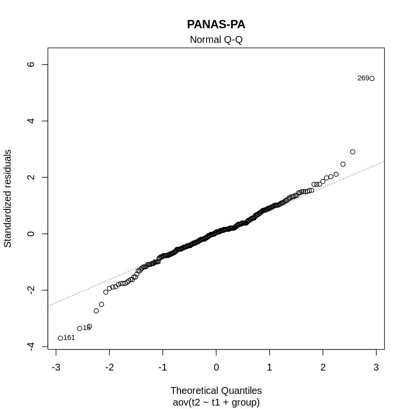

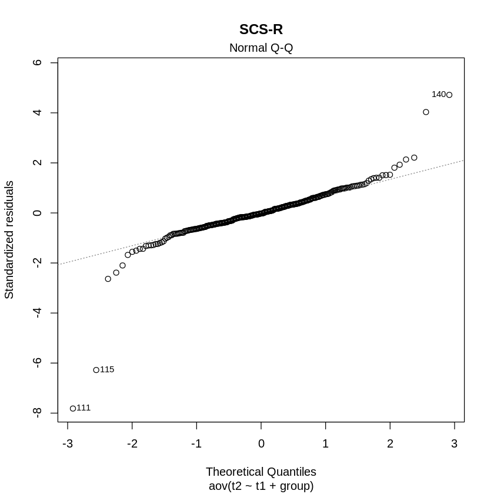

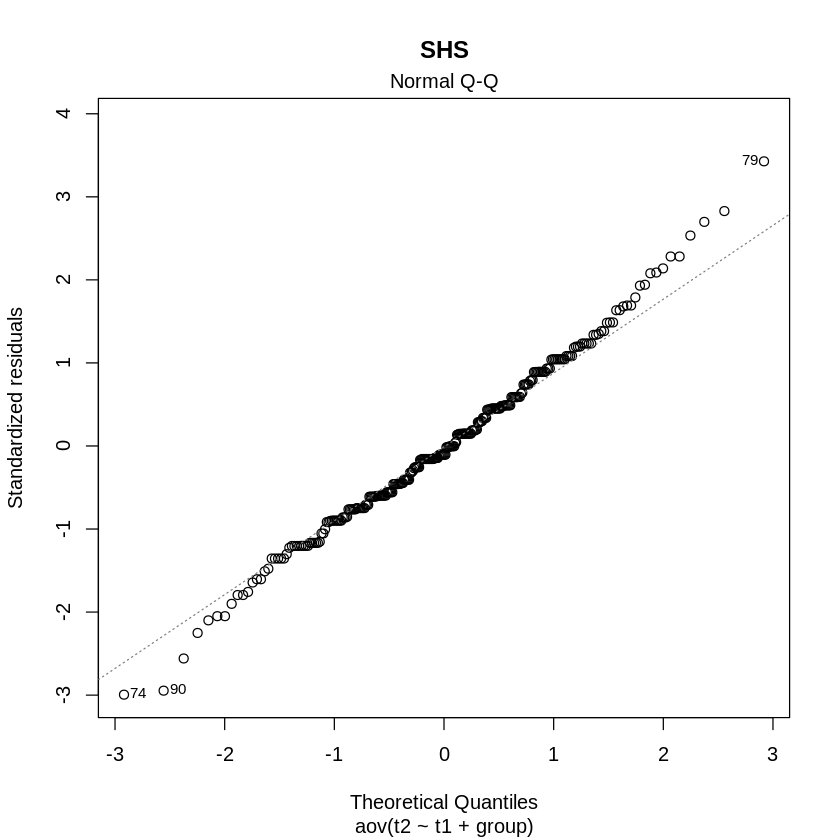

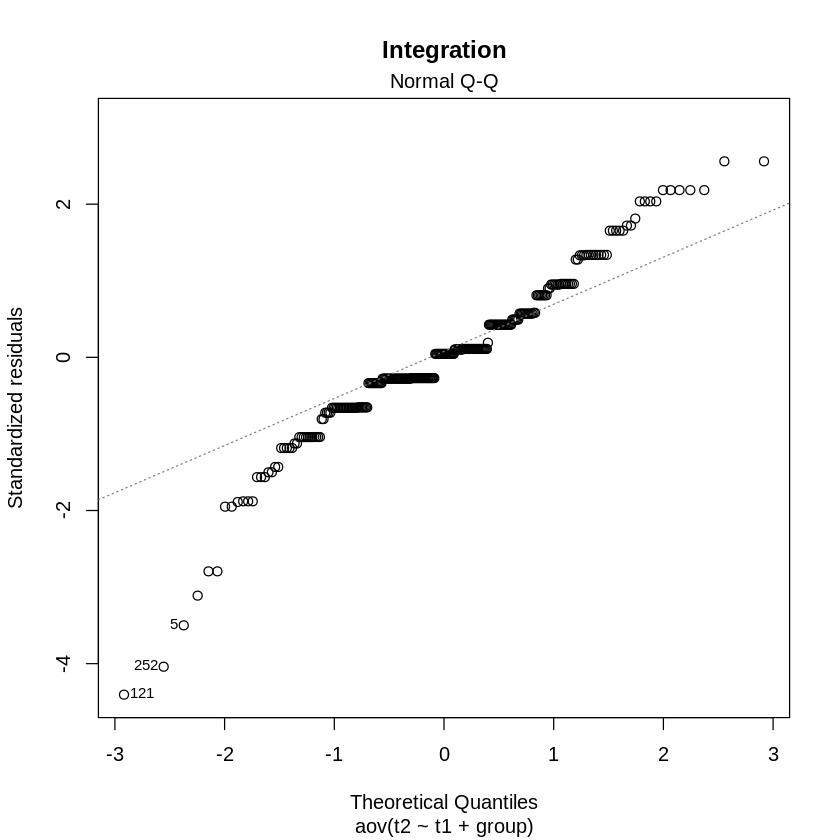

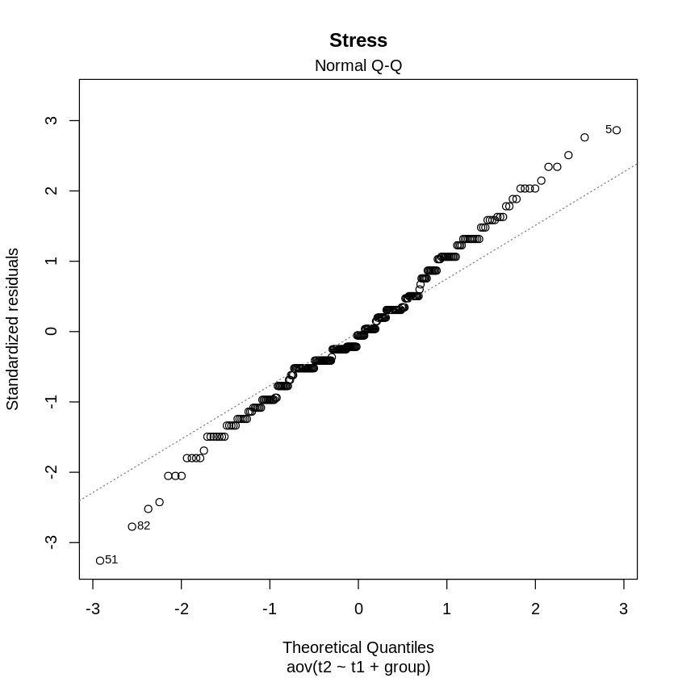

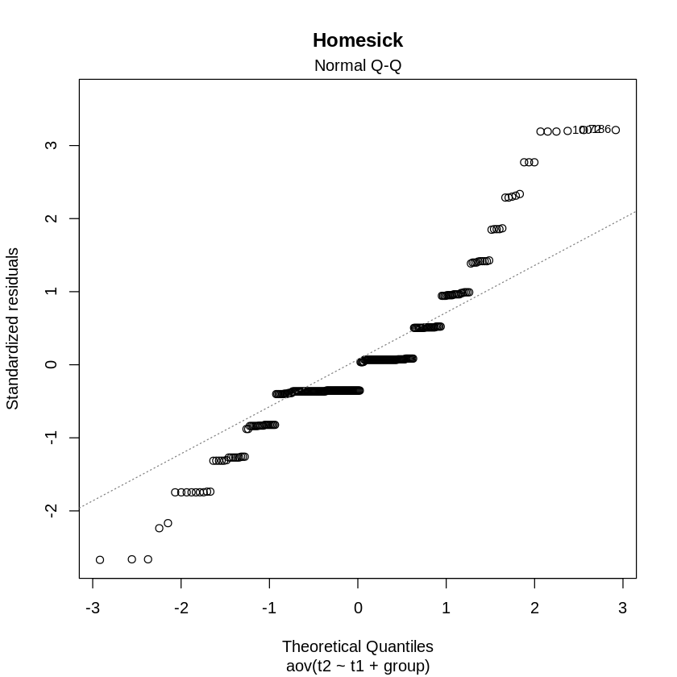

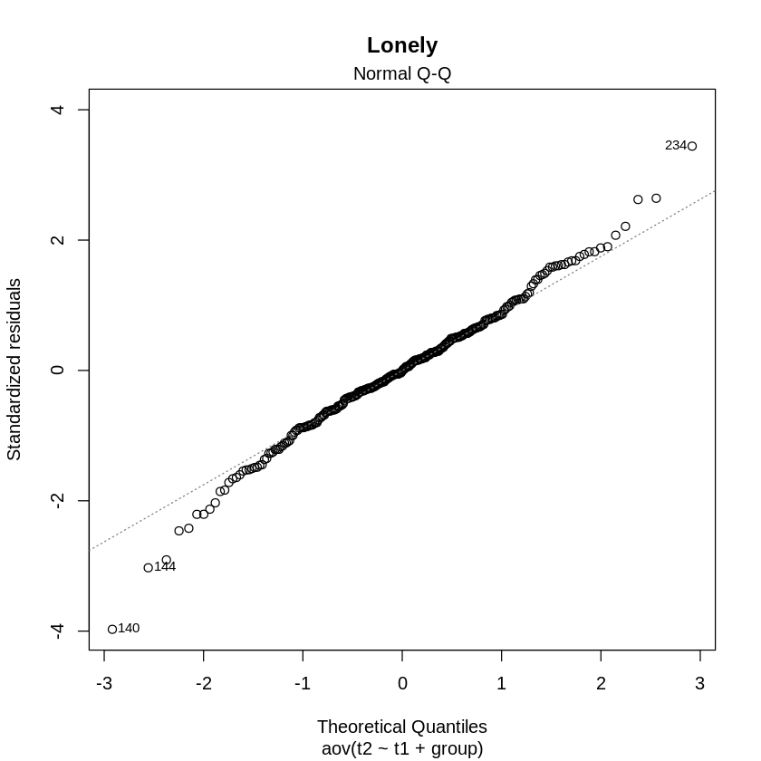

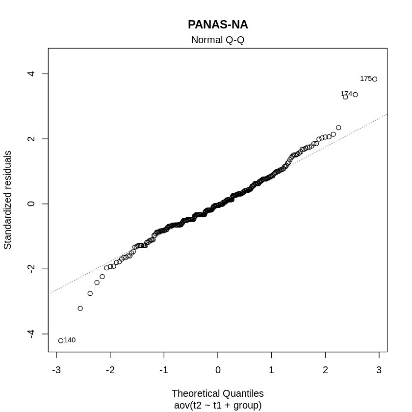

```r
plot(models$FS, which = 2, main = "FS")
plot(models$`PANAS-PA`, which = 2, main = "PANAS-PA")
plot(models$`SCS-R`, which = 2, main = "SCS-R")
plot(models$SHS, which = 2, main = "SHS")
plot(models$Integration, which = 2, main = "Integration")
plot(models$Stress, which = 2, main  = "Stress")
plot(models$Homesick, which = 2, main  = "Homesick")
plot(models$Lonely, which = 2, main  = "Lonely")
plot(models$`PANAS-NA`, which = 2, main  = "PANAS-NA")
```

```r
results3 <- map2(
    models, corrected_models,
    ~ tibble(
        contrast = factor(1:2,
            levels = 1:2,
            labels = c("Handler v. Indirect and Direct", "Indirect v. Direct")
        ),
        n = length(.x$residuals),
        B = .y[3:4, "Estimate"],
        SE = .y[3:4, "Std. Error"],
        t = abs(.y[3:4, "t value"]),
        df = n - 4,
        p = .y[3:4, "Pr(>|t|)"],
        d = t2d(t = .y[3:4, "t value"], n = df),
        LL90 = d.ci(d = d, n = df, alpha = .10)[1:2, 1],
        UL90 = d.ci(d = d, n = df, alpha = .10)[1:2, 3],
        LL95 = d.ci(d = d, n = df)[1:2, 1],
        UL95 = d.ci(d = d, n = df)[1:2, 3]
    )
)

results3 <- bind_rows(results3, .id = "Measure")

results3 <- arrange(results3, contrast)

results3$Measure <- factor(results3$Measure, levels = levels(dta_diff$measure))

results3
```

A tibble: 18 × 13

| Measure <fct> | contrast <fct> | n <int> | B <dbl> | SE <dbl> | t <dbl> | df <dbl> | p <dbl> | d <dbl> | LL90 <dbl> | UL90 <dbl> | LL95 <dbl> | UL95 <dbl> |
| --- | --- | --- | --- | --- | --- | --- | --- | --- | --- | --- | --- | --- |
| FS | Handler v. Indirect and Direct | 284 | 0.05268218 | 0.02880507 | 1.828920 | 280 | 6.847509e-02 | 0.2185978 | 0.02121749 | 0.41559079 | -0.0165610806 | 0.45336320 |
| PANAS-PA | Handler v. Indirect and Direct | 284 | 0.04980548 | 0.04010202 | 1.241969 | 280 | 2.152872e-01 | 0.1484437 | -0.04855939 | 0.34518044 | -0.0862746357 | 0.38289513 |
| SCS-R | Handler v. Indirect and Direct | 284 | 0.08922721 | 0.03243980 | 2.750548 | 280 | 6.337236e-03 | 0.3287533 | 0.13053063 | 0.52638968 | 0.0926174239 | 0.56430906 |
| SHS | Handler v. Indirect and Direct | 284 | 0.10424736 | 0.03162582 | 3.296274 | 280 | 1.106110e-03 | 0.3939801 | 0.19512191 | 0.59214092 | 0.1570971344 | 0.63016870 |
| Integration | Handler v. Indirect and Direct | 283 | 0.21124955 | 0.05606994 | 3.767608 | 279 | 2.010893e-04 | 0.4511215 | 0.25126649 | 0.65017602 | 0.2130570060 | 0.68838876 |
| Stress | Handler v. Indirect and Direct | 284 | -0.34808137 | 0.06948780 | 5.009244 | 280 | 9.690912e-07 | -0.5987192 | -0.79917741 | -0.39721079 | -0.8376882559 | -0.35871912 |
| Homesick | Handler v. Indirect and Direct | 284 | -0.10967163 | 0.06147159 | 1.784103 | 280 | 7.548976e-02 | -0.2132411 | -0.41020721 | -0.01589082 | -0.4479787796 | 0.02188227 |
| Lonely | Handler v. Indirect and Direct | 284 | -0.06392091 | 0.01794412 | 3.562221 | 280 | 4.320507e-04 | -0.4257668 | -0.62421415 | -0.22655941 | -0.6623089552 | -0.18847882 |
| PANAS-NA | Handler v. Indirect and Direct | 284 | -0.13495201 | 0.03690386 | 3.656854 | 280 | 3.049329e-04 | -0.4370776 | -0.63563737 | -0.23774431 | -0.6737526733 | -0.19963154 |
| FS | Indirect v. Direct | 284 | 0.02946717 | 0.02492737 | 1.182121 | 280 | 2.381606e-01 | 0.1412905 | -0.05568076 | 0.33800799 | -0.0933908061 | 0.37571909 |
| PANAS-PA | Indirect v. Direct | 284 | 0.07535830 | 0.03823624 | 1.970861 | 280 | 4.972458e-02 | 0.2355629 | 0.03806911 | 0.43263640 | 0.0002774757 | 0.47042926 |
| SCS-R | Indirect v. Direct | 284 | 0.06431532 | 0.03010435 | 2.136413 | 280 | 3.351274e-02 | 0.2553502 | 0.05772268 | 0.45252389 | 0.0199059268 | 0.49034192 |
| SHS | Indirect v. Direct | 284 | 0.06347497 | 0.02741215 | 2.315578 | 280 | 2.130405e-02 | 0.2767645 | 0.07897506 | 0.47405800 | 0.0411293311 | 0.51190496 |
| Integration | Indirect v. Direct | 283 | 0.12043551 | 0.04232461 | 2.845519 | 279 | 4.762586e-03 | 0.3407136 | 0.14202628 | 0.53879128 | 0.1040248954 | 0.57679777 |
| Stress | Indirect v. Direct | 284 | -0.32432636 | 0.05512822 | 5.883128 | 280 | 1.146346e-08 | -0.7031683 | -0.90517639 | -0.49993842 | -0.9440059979 | -0.46113593 |
| Homesick | Indirect v. Direct | 284 | -0.15655633 | 0.05632442 | 2.779546 | 280 | 5.812134e-03 | -0.3322193 | -0.52988078 | -0.13396324 | -0.5678089787 | -0.09604393 |
| Lonely | Indirect v. Direct | 284 | -0.06668292 | 0.01587280 | 4.201080 | 280 | 3.574753e-05 | -0.5021251 | -0.70136930 | -0.30199078 | -0.7396352704 | -0.26374064 |
| PANAS-NA | Indirect v. Direct | 284 | -0.13813656 | 0.03263509 | 4.232762 | 280 | 3.132658e-05 | -0.5059118 | -0.70520037 | -0.30572771 | -0.7434746112 | -0.26746881 |

## Results of the ANCOVAs and Planned Contrasts

```r
tbl3 <- results3

tbl3[, c("B", "SE", "t", "d", "LL95", "UL95")] <- sapply(
    tbl3[, c("B", "SE", "t", "d", "LL95", "UL95")],
    format_num
)

tbl3$p <- f_num(tbl3$p, digits = 3)
tbl3$p <- ifelse(tbl3$p == ".000", "<.001", tbl3$p)

tbl3$Measure <- as.character(tbl3$Measure)

keepers3 <- c("Measure", "B", "SE", "t", "p", "d", "LL95", "UL95")

tbl3 <- rbind(
    c("Handler v. Indirect and Direct", rep("", length(keepers3) - 1)),
    tbl3[tbl3$contrast == "Handler v. Indirect and Direct", keepers3],
    c("Indirect v. Direct", rep("", length(keepers3) - 1)),
    tbl3[tbl3$contrast == "Indirect v. Direct", keepers3]
)

write.csv(tbl3, row.names = FALSE, quote = FALSE)
```

```
Measure,B,SE,t,p,d,LL95,UL95
Handler v. Indirect and Direct,,,,,,,
FS,0.05,0.03,1.83,.068,0.22,−0.02,0.45
PANAS-PA,0.05,0.04,1.24,.215,0.15,−0.09,0.38
SCS-R,0.09,0.03,2.75,.006,0.33,0.09,0.56
SHS,0.10,0.03,3.30,.001,0.39,0.16,0.63
Integration,0.21,0.06,3.77,<.001,0.45,0.21,0.69
Stress,−0.35,0.07,5.01,<.001,−0.60,−0.84,−0.36
Homesick,−0.11,0.06,1.78,.075,−0.21,−0.45,0.02
Lonely,−0.06,0.02,3.56,<.001,−0.43,−0.66,−0.19
PANAS-NA,−0.13,0.04,3.66,<.001,−0.44,−0.67,−0.20
Indirect v. Direct,,,,,,,
FS,0.03,0.02,1.18,.238,0.14,−0.09,0.38
PANAS-PA,0.08,0.04,1.97,.050,0.24,0.00,0.47
SCS-R,0.06,0.03,2.14,.034,0.26,0.02,0.49
SHS,0.06,0.03,2.32,.021,0.28,0.04,0.51
Integration,0.12,0.04,2.85,.005,0.34,0.10,0.58
Stress,−0.32,0.06,5.88,<.001,−0.70,−0.94,−0.46
Homesick,−0.16,0.06,2.78,.006,−0.33,−0.57,−0.10
Lonely,−0.07,0.02,4.20,<.001,−0.50,−0.74,−0.26
PANAS-NA,−0.14,0.03,4.23,<.001,−0.51,−0.74,−0.27
```

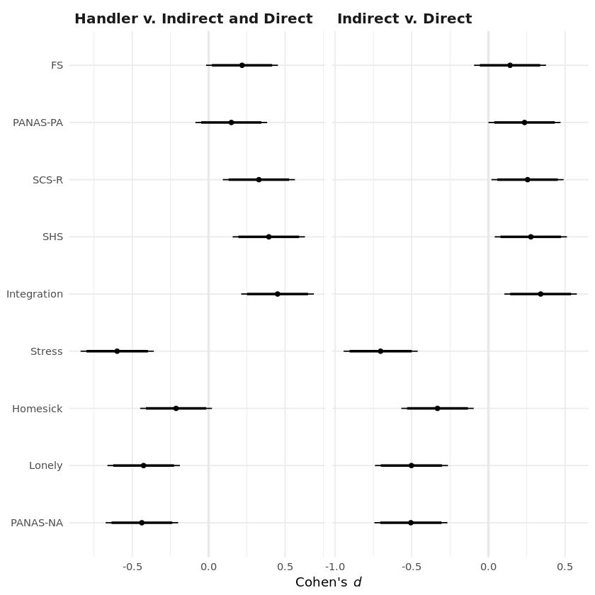

```r
ggplot(results3, aes(x = d, y = fct_rev(Measure))) +
    facet_wrap(~contrast, scales = "free_x") +
    geom_vline(xintercept = 0, size = 1.0, colour = "#e9e9e9") +
    geom_linerange(aes(xmin = LL95, xmax = UL95)) +
    geom_linerange(aes(xmin = LL90, xmax = UL90), size = 1) +
    geom_point() +
    theme_minimal(base_family = "Fira Sans") +
    labs(
        x = "Cohen's *d*",
        y = NULL
    ) +
    theme(
        axis.title.x = element_markdown(),
        strip.text = element_text(size = 12, hjust = 0, face = "bold")
    )
```

```r
ggsave("h3h4.png", width = 6.5, height = 4, dpi = 320)
```

# Exploratory Analyses

## Controlling for Pet Ownership

Pet ownership was imbalanced between groups and could affect the outcome of the intervention. Are the results different if we control for pet ownership?

```r
models_pet <- lapply(
    split(dta_diff, dta_diff$measure),
    function(x) aov(t2 ~ t1 + group + pets, data = x)
)

lapply(
    models_pet,
    function(x) lmtest::coeftest(x, vcov. = sandwich::vcovHC(x))
)
```

```
$FS

t test of coefficients:

                       Estimate Std. Error t value  Pr(>|t|)
(Intercept)            0.645058   0.184039  3.5050 0.0005329 ***
t1                     0.896174   0.030691 29.2000 < 2.2e-16 ***
grouphandler_v_dog     0.050378   0.030058  1.6760 0.0948712 .
groupindirect_v_direct 0.031426   0.025506  1.2321 0.2189636
petsYes                0.030301   0.045047  0.6727 0.5017263
---
Signif. codes:  0 ‘***’ 0.001 ‘**’ 0.01 ‘*’ 0.05 ‘.’ 0.1 ‘ ’ 1


$`PANAS-PA`

t test of coefficients:

                        Estimate Std. Error t value Pr(>|t|)
(Intercept)             0.408241   0.170341  2.3966  0.01722 *
t1                      0.883820   0.050764 17.4103  < 2e-16 ***
grouphandler_v_dog      0.053508   0.040843  1.3101  0.19125
groupindirect_v_direct  0.067751   0.038819  1.7453  0.08205 .
petsYes                -0.075160   0.071333 -1.0536  0.29297
---
Signif. codes:  0 ‘***’ 0.001 ‘**’ 0.01 ‘*’ 0.05 ‘.’ 0.1 ‘ ’ 1


$`SCS-R`

t test of coefficients:

                       Estimate Std. Error t value Pr(>|t|)
(Intercept)            0.405041   0.221068  1.8322  0.06800 .
t1                     0.931082   0.046986 19.8160  < 2e-16 ***
grouphandler_v_dog     0.082469   0.032976  2.5009  0.01297 *
groupindirect_v_direct 0.063741   0.030959  2.0589  0.04044 *
petsYes                0.056836   0.052674  1.0790  0.28153
---
Signif. codes:  0 ‘***’ 0.001 ‘**’ 0.01 ‘*’ 0.05 ‘.’ 0.1 ‘ ’ 1
```

[output cut: 69 more lines]

```
Signif. codes:  0 ‘***’ 0.001 ‘**’ 0.01 ‘*’ 0.05 ‘.’ 0.1 ‘ ’ 1


$`PANAS-NA`

t test of coefficients:

                        Estimate Std. Error t value  Pr(>|t|)
(Intercept)             0.242868   0.101890  2.3836 0.0178221 *
t1                      0.696194   0.055425 12.5610 < 2.2e-16 ***
grouphandler_v_dog     -0.136910   0.038350 -3.5700 0.0004212 ***
groupindirect_v_direct -0.135766   0.033189 -4.0907 5.653e-05 ***
petsYes                -0.023718   0.064705 -0.3666 0.7142325
---
Signif. codes:  0 ‘***’ 0.001 ‘**’ 0.01 ‘*’ 0.05 ‘.’ 0.1 ‘ ’ 1
```

## Composite Measure

Can we treat the ill-being and well-being items as measuring the same construct?

```r
z <- dta

varnames <- c(
    "flourishing",
    "panas_pa",
    "scs",
    "shs",
    "integration",
    "stress",
    "homesickness",
    "loneliness",
    "panas_na"
)

keys <- c("stress", "homesickness", "loneliness", "panas_na")

pretty_varnames <- levels(dta_diff$measure)[1:9]

drop <- c("homesickness", "stress", "integration", "panas_pa")
```

```r
ctt_t1 <- multi_ctt(
    x = z[z$time == "t1", ],
    varnames = varnames,
    keys = keys,
    drop = drop,
    pretty_varnames = levels(dta_diff$measure)[1:9]
)

write.csv(ctt_t1$rdrop, row.names = FALSE, quote = FALSE)
ctt_t1$alpha
```

```
Item,Step1,Step2,Step3,Step4,Step5
FS,.72,.73,.75,.80,.76
PANAS-PA,.42,.44,.44,.44,-
SCS-R,.78,.80,.83,.81,.83
SHS,.66,.68,.66,.70,.70
Integration,.34,.36,.39,-,-
Stress,.27,.28,-,-,-
Homesick,.22,-,-,-,-
Lonely,.75,.75,.77,.76,.78
PANAS-NA,.54,.56,.53,.55,.58
```

1. '.79'

2. '.82'

3. '.84'

4. '.87'

5. '.88'

```r
ctt_t2 <- multi_ctt(
    x = z[z$time == "t2", ],
    varnames = varnames,
    keys = keys,
    drop = drop,
    pretty_varnames = levels(dta_diff$measure)[1:9]
)

write.csv(ctt_t2$rdrop, row.names = FALSE, quote = FALSE)
ctt_t2$alpha
```

```
Item,Step1,Step2,Step3,Step4,Step5
FS,.66,.69,.72,.76,.72
PANAS-PA,.34,.37,.38,.39,-
SCS-R,.75,.76,.81,.79,.80
SHS,.65,.66,.65,.68,.68
Integration,.39,.42,.43,-,-
Stress,.38,.36,-,-,-
Homesick,.23,-,-,-,-
Lonely,.78,.78,.80,.77,.80
PANAS-NA,.49,.49,.42,.42,.46
```

1. '.79'

2. '.82'

3. '.83'

4. '.84'

5. '.86'

# Exploratory Factor Analysis

## With all Variables

This is an EFA with all 9 variables, including the variables which the reliability analysis indicated were not well represented by the other variables (i.e., homesickness, stress, integration, and positive affect).

```r
cormat <- cor(z[z$time == "t1", varnames], use = "pairwise.complete.obs")
```

### Parallel Analysis

The number of factors according to parallel analysis is found by comparing the observed principal component eigenvalues to principal component eigenvalues of a sample random normal deviates with the same number of variables and observations.

The results below indicate that the first component explains more variance than random data eigenvalues, but the remaining components do not. As such, one factor should be retained.

```r
set.seed(1234L)
cbind(
    ParallelAnalysis(n_obs = 284, n_vars = 9),
    observed = eigen(cormat, only.values = TRUE)$values
)
```

A matrix: 9 × 3 of type dbl

| 50% | 95% | observed |
| --- | --- | --- |
| 1.2774524 | 1.3666655 | 4.10956694 |
| 1.1829021 | 1.2430673 | 1.04720639 |
| 1.1111807 | 1.1621184 | 0.96529336 |
| 1.0508972 | 1.0920646 | 0.85591454 |
| 0.9938312 | 1.0304687 | 0.71522799 |
| 0.9363919 | 0.9778409 | 0.50288798 |
| 0.8799228 | 0.9208879 | 0.44297754 |
| 0.8178225 | 0.8659311 | 0.28015716 |
| 0.7459072 | 0.8014340 | 0.08076809 |

Below shows the result of common factor analysis using maximum likelihood factor analysis.

`ML1` is the loadings standardized loadings on the first (and only) factor (i.e., it is the correlation between the item and the factor). `h2` is the communality. That is, the proportion of variance in the variable that is explained by the entire solution. Because it is a 1-factor solution, this is the same as the squared loading on the factor. `u2` is just `1 - h2`, or the unexplained variance.

Note that the soluation explains very little variance in homesickness, stress, integration, and positive affect.

```r
fa_result <- fa(z[, varnames], nfactors = 1, fm = "ml")

fa_result
```

```
Factor Analysis using method =  ml
Call: fa(r = z[, varnames], nfactors = 1, fm = "ml")
Standardized loadings (pattern matrix) based upon correlation matrix
               ML1    h2    u2 com
flourishing   0.74 0.546 0.454   1
panas_pa      0.40 0.157 0.843   1
scs           0.95 0.909 0.091   1
shs           0.68 0.460 0.540   1
integration   0.48 0.232 0.768   1
stress       -0.30 0.089 0.911   1
homesickness -0.26 0.068 0.932   1
loneliness   -0.91 0.829 0.171   1
panas_na     -0.53 0.284 0.716   1

                ML1
SS loadings    3.57
Proportion Var 0.40

Mean item complexity =  1
Test of the hypothesis that 1 factor is sufficient.

The degrees of freedom for the null model are  36  and the objective function was  4.15 with Chi Square of  2339.5
The degrees of freedom for the model are 27  and the objective function was  0.59

The root mean square of the residuals (RMSR) is  0.08
The df corrected root mean square of the residuals is  0.09

The harmonic number of observations is  568 with the empirical chi square  248.88  with prob <  9.1e-38
The total number of observations was  568  with Likelihood Chi Square =  333.37  with prob <  1.5e-54

Tucker Lewis Index of factoring reliability =  0.822
RMSEA index =  0.141  and the 90 % confidence intervals are  0.128 0.155
BIC =  162.13
Fit based upon off diagonal values = 0.96
Measures of factor score adequacy
                                                   ML1
Correlation of (regression) scores with factors   0.97
Multiple R square of scores with factors          0.95
Minimum correlation of possible factor scores     0.89
```

## With a Subset of Well-being Indicators

The reliability analysis and EFA both suggest that homesickness, stress, integration, and positive affect are not well represented by this common factor. Below shows an EFA with those items excluded.

### Parallel Analysis

Parallel analysis shows even stronger evidence for a unidimensional solution. The observed eigenvalue for the second component is 0.58 (i.e., the second component explains 58% of the variance explained by one variable), which is much less than either the mean or 95th percentile random data eigenvalues.

```r
set.seed(1234L)
cormat2 <- cor(
    z[z$time == "t1", varnames[-which(varnames %in% drop)]],
    use = "pairwise.complete.obs"
)

cbind(
    ParallelAnalysis(n_obs = 284, n_vars = 5),
    observed = eigen(cormat2, only.values = TRUE)$values
)
```

A matrix: 5 × 3 of type dbl

| 50% | 95% | observed |
| --- | --- | --- |
| 1.1652737 | 1.2470997 | 3.47845623 |
| 1.0669686 | 1.1250723 | 0.58831769 |
| 0.9990498 | 1.0419693 | 0.52784112 |
| 0.9262531 | 0.9716274 | 0.32098205 |
| 0.8410315 | 0.9020703 | 0.08440292 |

### EFA Results

The results of a maximum likelihood factor analysis with only flourishing, social connectedness, happiness, loneliness, and negative affect.

The loadings are all fairly large and the factor explains 60% of the variance in the 5 items.

```r
fa_result2 <- fa(
    z[, varnames[-which(varnames %in% drop)]],
    nfactors = 1,
    fm = "ml"
)

fa_result2
```

```
Factor Analysis using method =  ml
Call: fa(r = z[, varnames[-which(varnames %in% drop)]], nfactors = 1,
    fm = "ml")
Standardized loadings (pattern matrix) based upon correlation matrix
              ML1   h2    u2 com
flourishing  0.73 0.54 0.461   1
scs          0.96 0.93 0.074   1
shs          0.67 0.45 0.552   1
loneliness  -0.91 0.82 0.177   1
panas_na    -0.52 0.27 0.726   1

                ML1
SS loadings    3.01
Proportion Var 0.60

Mean item complexity =  1
Test of the hypothesis that 1 factor is sufficient.

The degrees of freedom for the null model are  10  and the objective function was  3.24 with Chi Square of  1827.29
The degrees of freedom for the model are 5  and the objective function was  0.24

The root mean square of the residuals (RMSR) is  0.07
The df corrected root mean square of the residuals is  0.1

The harmonic number of observations is  568 with the empirical chi square  53.17  with prob <  3.1e-10
The total number of observations was  568  with Likelihood Chi Square =  133.03  with prob <  5.4e-27

Tucker Lewis Index of factoring reliability =  0.859
RMSEA index =  0.212  and the 90 % confidence intervals are  0.182 0.244
BIC =  101.31
Fit based upon off diagonal values = 0.99
Measures of factor score adequacy
                                                   ML1
Correlation of (regression) scores with factors   0.98
Multiple R square of scores with factors          0.95
Minimum correlation of possible factor scores     0.90
```

### Factor Scores

The factor scores are computed using regression with the standardized loadings.

Below is just wrangling the data to add each participants' factor score at each measurement occasion.

```r
z$comp <- fa_result2$scores[, 1]
```

```r
z <- z[, c("pid", "group", "time", "comp")]

z <- pivot_wider(
    z,
    names_from = "time",
    values_from = "comp"
)

z$measure <- "Composite"

z$diff21 <- z$t2 - z$t1
```

# Hypothesis Tests with Factor Scores

We conducted the four null hypothesis significance tests using factor scores.

## H1: Effect of the Intervention

Factor scores significantly increased pre-to-post intervention in all three conditions.

```r
comp_h1 <- lapply(
    split(z, z$group),
    t_test, h = "post"
)

comp_h1 <- bind_rows(comp_h1, .id = "Condition")

rownames(comp_h1) <- NULL

comp_h1[, -1] <- round(comp_h1[, -1], 3)

comp_h1
```

A data.frame: 3 × 9

| Condition <chr> | t <dbl> | df <dbl> | p <dbl> | d <dbl> | d90.LL <dbl> | d90.UL <dbl> | d95.LL <dbl> | d95.UL <dbl> |
| --- | --- | --- | --- | --- | --- | --- | --- | --- |
| Handler | 1.862 | 93 | 0.033 | 0.192 | 0.020 | 0.363 | -0.013 | 0.396 |
| Indirect | 3.796 | 94 | 0.000 | 0.389 | 0.213 | 0.564 | 0.180 | 0.597 |
| Direct | 7.767 | 94 | 0.000 | 0.797 | 0.601 | 0.989 | 0.564 | 1.026 |

## H3 and H4: Effect of the Canines

Both contrasts were significant, indicating a significant effect of both the dog's presence, and direct physical contact with the canine.

```r
contrasts(z$group) <- cbind(
    handler_v_dog = c(-1, 0.5, 0.5),
    indirect_v_direct = c(0, -1, 1)
)

model <- aov(t2 ~ t1 + group, data = z)
corrected_model <- lmtest::coeftest(model, vcov. = sandwich::vcovHC(model))

round(corrected_model, 3)

ds <- t2d(corrected_model[3:4, "t value"], n = 280)
round(d.ci(ds, n = c(280, 280)), 2)
```

```
t test of coefficients:

                       Estimate Std. Error t value Pr(>|t|)
(Intercept)               0.181      0.022   8.308   <2e-16 ***
t1                        0.935      0.039  24.253   <2e-16 ***
grouphandler_v_dog        0.116      0.031   3.778   <2e-16 ***
groupindirect_v_direct    0.093      0.030   3.133    0.002 **
---
Signif. codes:  0 ‘***’ 0.001 ‘**’ 0.01 ‘*’ 0.05 ‘.’ 0.1 ‘ ’ 1
```

A matrix: 2 × 3 of type dbl

|  | lower | effect | upper |
| --- | --- | --- | --- |
| grouphandler_v_dog | 0.21 | 0.45 | 0.69 |
| groupindirect_v_direct | 0.14 | 0.37 | 0.61 |

```r
dta$comp <- fa_result2$scores[, 1]
```

```r
head(dta)
```

A data.frame: 6 × 14

|  | pid <int> | group <fct> | time <fct> | pets <chr> | stress <int> | homesickness <int> | loneliness <dbl> | panas_pa <dbl> | panas_na <dbl> | shs <dbl> | scs <dbl> | flourishing <dbl> | integration <int> | comp <dbl> |
| --- | --- | --- | --- | --- | --- | --- | --- | --- | --- | --- | --- | --- | --- | --- |
| 1 | 1 | Handler | t1 | No | 2 | 3 | 2.25 | 3.2 | 1.0 | 2.333333 | 3.900000 | 6.125 | 1 | -0.5516554 |
| 2 | 1 | Handler | t2 | No | 2 | 3 | 1.70 | 3.8 | 1.2 | 3.333333 | 3.800000 | 6.000 | 2 | -0.3227439 |
| 3 | 2 | Direct | t1 | No | 2 | 4 | 1.90 | 3.0 | 1.8 | 3.333333 | 5.150000 | 5.250 | 4 | 0.4879954 |
| 4 | 2 | Direct | t2 | No | 1 | 2 | 1.60 | 3.2 | 1.0 | 4.000000 | 5.263158 | 6.000 | 4 | 0.8731664 |
| 5 | 3 | Indirect | t1 | No | 4 | 3 | 2.25 | 2.8 | 1.6 | 2.666667 | 4.100000 | 5.375 | 3 | -0.4837059 |
| 6 | 3 | Indirect | t2 | No | 3 | 2 | 2.25 | 3.0 | 1.6 | 3.333333 | 4.150000 | 5.375 | 3 | -0.4002878 |

```r
cor_tbl_r <- lapply(split(dta[, c(varnames, "comp")], dta$time), function(x) round(corr.test(x)$r, 3))
cor_tbl_r
```

**$t1**

A matrix: 10 × 10 of type dbl

|  | flourishing | panas_pa | scs | shs | integration | stress | homesickness | loneliness | panas_na | comp |
| --- | --- | --- | --- | --- | --- | --- | --- | --- | --- | --- |
| flourishing | 1.000 | 0.524 | 0.732 | 0.684 | 0.282 | -0.234 | -0.213 | -0.589 | -0.498 | 0.763 |
| panas_pa | 0.524 | 1.000 | 0.394 | 0.363 | 0.230 | -0.163 | -0.074 | -0.311 | -0.197 | 0.405 |
| scs | 0.732 | 0.394 | 1.000 | 0.633 | 0.445 | -0.230 | -0.224 | -0.889 | -0.524 | 0.988 |
| shs | 0.684 | 0.363 | 0.633 | 1.000 | 0.263 | -0.303 | -0.196 | -0.578 | -0.468 | 0.690 |
| integration | 0.282 | 0.230 | 0.445 | 0.263 | 1.000 | -0.028 | -0.085 | -0.419 | -0.213 | 0.441 |
| stress | -0.234 | -0.163 | -0.230 | -0.303 | -0.028 | 1.000 | 0.078 | 0.206 | 0.312 | -0.250 |
| homesickness | -0.213 | -0.074 | -0.224 | -0.196 | -0.085 | 0.078 | 1.000 | 0.277 | 0.125 | -0.249 |
| loneliness | -0.589 | -0.311 | -0.889 | -0.578 | -0.419 | 0.206 | 0.277 | 1.000 | 0.548 | -0.931 |
| panas_na | -0.498 | -0.197 | -0.524 | -0.468 | -0.213 | 0.312 | 0.125 | 0.548 | 1.000 | -0.583 |
| comp | 0.763 | 0.405 | 0.988 | 0.690 | 0.441 | -0.250 | -0.249 | -0.931 | -0.583 | 1.000 |

**$t2**

A matrix: 10 × 10 of type dbl

|  | flourishing | panas_pa | scs | shs | integration | stress | homesickness | loneliness | panas_na | comp |
| --- | --- | --- | --- | --- | --- | --- | --- | --- | --- | --- |
| flourishing | 1.000 | 0.468 | 0.691 | 0.649 | 0.293 | -0.244 | -0.144 | -0.625 | -0.356 | 0.743 |
| panas_pa | 0.468 | 1.000 | 0.354 | 0.323 | 0.175 | -0.163 | -0.004 | -0.308 | -0.091 | 0.371 |
| scs | 0.691 | 0.354 | 1.000 | 0.611 | 0.480 | -0.239 | -0.212 | -0.872 | -0.432 | 0.986 |
| shs | 0.649 | 0.323 | 0.611 | 1.000 | 0.303 | -0.311 | -0.216 | -0.591 | -0.383 | 0.675 |
| integration | 0.293 | 0.175 | 0.480 | 0.303 | 1.000 | -0.158 | -0.064 | -0.501 | -0.216 | 0.492 |
| stress | -0.244 | -0.163 | -0.239 | -0.311 | -0.158 | 1.000 | 0.198 | 0.295 | 0.445 | -0.285 |
| homesickness | -0.144 | -0.004 | -0.212 | -0.216 | -0.064 | 0.198 | 1.000 | 0.275 | 0.202 | -0.241 |
| loneliness | -0.625 | -0.308 | -0.872 | -0.591 | -0.501 | 0.295 | 0.275 | 1.000 | 0.444 | -0.928 |
| panas_na | -0.356 | -0.091 | -0.432 | -0.383 | -0.216 | 0.445 | 0.202 | 0.444 | 1.000 | -0.482 |
| comp | 0.743 | 0.371 | 0.986 | 0.675 | 0.492 | -0.285 | -0.241 | -0.928 | -0.482 | 1.000 |

```r
cor_tbl_p <- lapply(split(dta[, c(varnames, "comp")], dta$time), function(x) round(corr.test(x)$p, 3))
cor_tbl_p
```

**$t1**

A matrix: 10 × 10 of type dbl

|  | flourishing | panas_pa | scs | shs | integration | stress | homesickness | loneliness | panas_na | comp |
| --- | --- | --- | --- | --- | --- | --- | --- | --- | --- | --- |
| flourishing | 0 | 0.000 | 0 | 0.000 | 0.000 | 0.001 | 0.003 | 0.000 | 0.000 | 0 |
| panas_pa | 0 | 0.000 | 0 | 0.000 | 0.001 | 0.036 | 0.604 | 0.000 | 0.007 | 0 |
| scs | 0 | 0.000 | 0 | 0.000 | 0.000 | 0.001 | 0.002 | 0.000 | 0.000 | 0 |
| shs | 0 | 0.000 | 0 | 0.000 | 0.000 | 0.000 | 0.007 | 0.000 | 0.000 | 0 |
| integration | 0 | 0.000 | 0 | 0.000 | 0.000 | 0.637 | 0.604 | 0.000 | 0.003 | 0 |
| stress | 0 | 0.006 | 0 | 0.000 | 0.637 | 0.000 | 0.604 | 0.004 | 0.000 | 0 |
| homesickness | 0 | 0.211 | 0 | 0.001 | 0.151 | 0.190 | 0.000 | 0.000 | 0.175 | 0 |
| loneliness | 0 | 0.000 | 0 | 0.000 | 0.000 | 0.000 | 0.000 | 0.000 | 0.000 | 0 |
| panas_na | 0 | 0.001 | 0 | 0.000 | 0.000 | 0.000 | 0.035 | 0.000 | 0.000 | 0 |
| comp | 0 | 0.000 | 0 | 0.000 | 0.000 | 0.000 | 0.000 | 0.000 | 0.000 | 0 |

**$t2**

A matrix: 10 × 10 of type dbl

|  | flourishing | panas_pa | scs | shs | integration | stress | homesickness | loneliness | panas_na | comp |
| --- | --- | --- | --- | --- | --- | --- | --- | --- | --- | --- |
| flourishing | 0.000 | 0.000 | 0 | 0 | 0.000 | 0.000 | 0.061 | 0 | 0.000 | 0.000 |
| panas_pa | 0.000 | 0.000 | 0 | 0 | 0.022 | 0.035 | 0.952 | 0 | 0.379 | 0.000 |
| scs | 0.000 | 0.000 | 0 | 0 | 0.000 | 0.001 | 0.003 | 0 | 0.000 | 0.000 |
| shs | 0.000 | 0.000 | 0 | 0 | 0.000 | 0.000 | 0.003 | 0 | 0.000 | 0.000 |
| integration | 0.000 | 0.003 | 0 | 0 | 0.000 | 0.039 | 0.561 | 0 | 0.003 | 0.000 |
| stress | 0.000 | 0.006 | 0 | 0 | 0.008 | 0.000 | 0.006 | 0 | 0.000 | 0.000 |
| homesickness | 0.015 | 0.952 | 0 | 0 | 0.280 | 0.001 | 0.000 | 0 | 0.005 | 0.001 |
| loneliness | 0.000 | 0.000 | 0 | 0 | 0.000 | 0.000 | 0.000 | 0 | 0.000 | 0.000 |
| panas_na | 0.000 | 0.126 | 0 | 0 | 0.000 | 0.000 | 0.001 | 0 | 0.000 | 0.000 |
| comp | 0.000 | 0.000 | 0 | 0 | 0.000 | 0.000 | 0.000 | 0 | 0.000 | 0.000 |

```r
cor_tbl_sig <- lapply(
    cor_tbl_p,
    function(x) {
        x <- ifelse(x < .001, "***", ifelse(x < .01, "**", ifelse(x < .05, "*", "")))
        x[upper.tri(x, diag = TRUE)] <- ""
        x
    }
)
cor_tbl_sig
```

**$t1**

A matrix: 10 × 10 of type chr

|  | flourishing | panas_pa | scs | shs | integration | stress | homesickness | loneliness | panas_na | comp |
| --- | --- | --- | --- | --- | --- | --- | --- | --- | --- | --- |
| flourishing |  |  |  |  |  |  |  |  |  |  |
| panas_pa | *** |  |  |  |  |  |  |  |  |  |
| scs | *** | *** |  |  |  |  |  |  |  |  |
| shs | *** | *** | *** |  |  |  |  |  |  |  |
| integration | *** | *** | *** | *** |  |  |  |  |  |  |
| stress | *** | ** | *** | *** |  |  |  |  |  |  |
| homesickness | *** |  | *** | ** |  |  |  |  |  |  |
| loneliness | *** | *** | *** | *** | *** | *** | *** |  |  |  |
| panas_na | *** | ** | *** | *** | *** | *** | * | *** |  |  |
| comp | *** | *** | *** | *** | *** | *** | *** | *** | *** |  |

**$t2**

A matrix: 10 × 10 of type chr

|  | flourishing | panas_pa | scs | shs | integration | stress | homesickness | loneliness | panas_na | comp |
| --- | --- | --- | --- | --- | --- | --- | --- | --- | --- | --- |
| flourishing |  |  |  |  |  |  |  |  |  |  |
| panas_pa | *** |  |  |  |  |  |  |  |  |  |
| scs | *** | *** |  |  |  |  |  |  |  |  |
| shs | *** | *** | *** |  |  |  |  |  |  |  |
| integration | *** | ** | *** | *** |  |  |  |  |  |  |
| stress | *** | ** | *** | *** | ** |  |  |  |  |  |
| homesickness | * |  | *** | *** |  | ** |  |  |  |  |
| loneliness | *** | *** | *** | *** | *** | *** | *** |  |  |  |
| panas_na | *** |  | *** | *** | *** | *** | ** | *** |  |  |
| comp | *** | *** | *** | *** | *** | *** | *** | *** | *** |  |

```r
cor_tbl_m <- lapply(split(dta[, c(varnames, "comp")], dta$time),
    colMeans,
    na.rm = TRUE
)
cor_tbl_m

cor_tbl_sd <- lapply(split(dta[, c(varnames, "comp")], dta$time),
    sapply,
    sd,
    na.rm = TRUE
)
cor_tbl_sd
```

**$t1**

**flourishing**

5.67787977867203

**panas_pa**

3.28908450704225

**scs**

4.41613232023721

**shs**

3.31103286384977

**integration**

3.22183098591549

**stress**

3.20774647887324

**homesickness**

2.08802816901408

**loneliness**

2.04018717568569

**panas_na**

1.97869718309859

**comp**

-0.0935518891776789

**$t2**

**flourishing**

5.74201458752515

**panas_pa**

3.2955985915493

**scs**

4.53423883946957

**shs**

3.53403755868545

**integration**

3.35335689045936

**stress**

2.37323943661972

**homesickness**

1.8943661971831

**loneliness**

1.91404744255004

**panas_na**

1.61285211267606

**comp**

0.0935518891776793

**$t1**

**flourishing**

0.78207518362171

**panas_pa**

0.682844192120855

**scs**

0.823891866633276

**shs**

0.875825679921248

**integration**

1.04834489760614

**stress**

0.970852522792361

**homesickness**

1.20481849984894

**loneliness**

0.530448811354172

**panas_na**

0.704838447163469

**comp**

0.960755754009622

**$t2**

**flourishing**

0.779902129442693

**panas_pa**

0.787192080670786

**scs**

0.866805525117641

**shs**

0.82273322631227

**integration**

1.02567104993462

**stress**

1.03034629966718

**homesickness**

1.1134116321464

**loneliness**

0.534739670867953

**panas_na**

0.671230055375456

**comp**

0.982357661533885

```r
tbl5 <- lapply(cor_tbl_r, f_num, digits = 2)
tbl5 <- lapply(tbl5, function(x) gsub("-", "−", x))
tbl5 <- lapply(tbl5, matrix, ncol = 10)
tbl5 <- lapply(tbl5, function(x) {
    x[upper.tri(x, diag = TRUE)] <- ""
    x
})
tbl5$t1 <- matrix(paste0(tbl5$t1, cor_tbl_sig$t1), ncol = 10)
tbl5$t2 <- matrix(paste0(tbl5$t2, cor_tbl_sig$t2), ncol = 10)
tbl5 <- lapply(tbl5,
    matrix, ncol = 10,
    dimnames = list(
        c(levels(dta_diff$measure)[1:9], "Composite"),
        1:10
    )
)
tbl5$t1 <- cbind(
    Variable = rownames(tbl5$t1),
    M = format_num(cor_tbl_m$t1),
    SD = format_num(cor_tbl_sd$t1),
    tbl5$t1
)[, 1:12]
tbl5$t2 <- cbind(
    Variable = rownames(tbl5$t2),
    M = format_num(cor_tbl_m$t2),
    SD = format_num(cor_tbl_sd$t2),
    tbl5$t2
)[, 1:12]

tbl5 <- rbind(
    c("Pre-intervention", rep("", 11)),
    tbl5$t1,
    c("Post-intervention", rep("", 11)),
    tbl5$t2
)
rownames(tbl5) <- NULL
tbl5
```

A matrix: 22 × 12 of type chr

| Variable | M | SD | 1 | 2 | 3 | 4 | 5 | 6 | 7 | 8 | 9 |
| --- | --- | --- | --- | --- | --- | --- | --- | --- | --- | --- | --- |
| Pre-intervention |  |  |  |  |  |  |  |  |  |  |  |
| FS | 5.68 | 0.78 |  |  |  |  |  |  |  |  |  |
| PANAS-PA | 3.29 | 0.68 | .52*** |  |  |  |  |  |  |  |  |
| SCS-R | 4.42 | 0.82 | .73*** | .39*** |  |  |  |  |  |  |  |
| SHS | 3.31 | 0.88 | .68*** | .36*** | .63*** |  |  |  |  |  |  |
| Integration | 3.22 | 1.05 | .28*** | .23*** | .44*** | .26*** |  |  |  |  |  |
| Stress | 3.21 | 0.97 | −.23*** | −.16** | −.23*** | −.30*** | −.03 |  |  |  |  |
| Homesick | 2.09 | 1.20 | −.21*** | −.07 | −.22*** | −.20** | −.09 | .08 |  |  |  |
| Lonely | 2.04 | 0.53 | −.59*** | −.31*** | −.89*** | −.58*** | −.42*** | .21*** | .28*** |  |  |
| PANAS-NA | 1.98 | 0.70 | −.50*** | −.20** | −.52*** | −.47*** | −.21*** | .31*** | .12* | .55*** |  |
| Composite | −0.09 | 0.96 | .76*** | .41*** | .99*** | .69*** | .44*** | −.25*** | −.25*** | −.93*** | −.58*** |
| Post-intervention |  |  |  |  |  |  |  |  |  |  |  |
| FS | 5.74 | 0.78 |  |  |  |  |  |  |  |  |  |
| PANAS-PA | 3.30 | 0.79 | .47*** |  |  |  |  |  |  |  |  |
| SCS-R | 4.53 | 0.87 | .69*** | .35*** |  |  |  |  |  |  |  |
| SHS | 3.53 | 0.82 | .65*** | .32*** | .61*** |  |  |  |  |  |  |
| Integration | 3.35 | 1.03 | .29*** | .17** | .48*** | .30*** |  |  |  |  |  |
| Stress | 2.37 | 1.03 | −.24*** | −.16** | −.24*** | −.31*** | −.16** |  |  |  |  |
| Homesick | 1.89 | 1.11 | −.14* | −.00 | −.21*** | −.22*** | −.06 | .20** |  |  |  |
| Lonely | 1.91 | 0.53 | −.62*** | −.31*** | −.87*** | −.59*** | −.50*** | .30*** | .28*** |  |  |
| PANAS-NA | 1.61 | 0.67 | −.36*** | −.09 | −.43*** | −.38*** | −.22*** | .44*** | .20** | .44*** |  |
| Composite | 0.09 | 0.98 | .74*** | .37*** | .99*** | .68*** | .49*** | −.28*** | −.24*** | −.93*** | −.48*** |